# Tarea 11_Ricardo Zamora Mennigke_Mineria de Datos 1

```r
Score5 <- prediccion5$prediction[,2]
Clase5 <- ttesting$tipo

plotROC(Score, Clase)
plotROC(Score2, Clase2, adicionar=TRUE, color = "blue")
plotROC(Score4, Clase4, adicionar = TRUE, color = "green")
plotROC(Score5, Clase5, adicionar = TRUE, color = "blueviolet")
```

```r
areaROC(Score5, Clase5)
```

```
## [1] 0.5
```

```r
modelo6 <- train.knn(tipo ~ ., data = taprendizaje,  kmax = 100, kernel = "epanechnikov")
prediccion6 <- predict(modelo6, ttesting, type = "prob")
head(prediccion6$prediction)
```

```
##               0 1
## [1,] 0.00000000 1
## [2,] 0.06568474 1
## [3,] 0.00000000 1
## [4,] 0.00000000 1
## [5,] 0.00000000 1
## [6,] 0.00000000 1
```

```r
modelo7 <- train.knn(tipo ~ ., data = taprendizaje,  kmax = 100, kernel = "biweight")
prediccion7 <- predict(modelo7, ttesting, type = "prob")
head(prediccion7$prediction)
```

```
##               0 1
## [1,] 0.00000000 1
## [2,] 0.05375467 1
## [3,] 0.00000000 1
## [4,] 0.00000000 1
## [5,] 0.00000000 1
## [6,] 0.00000000 1
```

```r
modelo8 <- train.knn(tipo ~ ., data = taprendizaje,  kmax = 100, kernel = "cos")
prediccion8 <- predict(modelo8, ttesting, type = "prob")
head(prediccion8$prediction)
```

```
##               0 1
## [1,] 0.00000000 1
## [2,] 0.06308365 1
## [3,] 0.00000000 1
## [4,] 0.00000000 1
## [5,] 0.00000000 1
## [6,] 0.00000000 1
```

```r
modelo9 <- train.knn(tipo ~ ., data = taprendizaje,  kmax = 100, kernel = "inv")
prediccion9 <- predict(modelo9, ttesting, type = "prob")
head(prediccion9$prediction)
```

```
##               0 1
## [1,] 0.00000000 1
## [2,] 0.08799309 1
## [3,] 0.00000000 1
## [4,] 0.00000000 1
## [5,] 0.00000000 1
## [6,] 0.00000000 1
```

```r
modelo10 <- train.knn(tipo ~ ., data = taprendizaje,  kmax = 100, kernel = "gaussian")
prediccion10 <- predict(modelo10, ttesting, type = "prob")
head(prediccion10$prediction)
```

```
##               0 1
## [1,] 0.00000000 1
## [2,] 0.07464869 1
## [3,] 0.00000000 1
## [4,] 0.00000000 1
## [5,] 0.00000000 1
## [6,] 0.00000000 1
```

```r
modelo11 <- train.knn(tipo ~ ., data = taprendizaje,  kmax = 100, kernel = "optimal")
prediccion11 <- predict(modelo11, ttesting, type = "prob")
head(prediccion11$prediction)
```

```
##               0 1
## [1,] 0.00000000 1
## [2,] 0.05863193 1
## [3,] 0.00000000 1
## [4,] 0.00000000 1
## [5,] 0.00000000 1
## [6,] 0.00000000 1
```

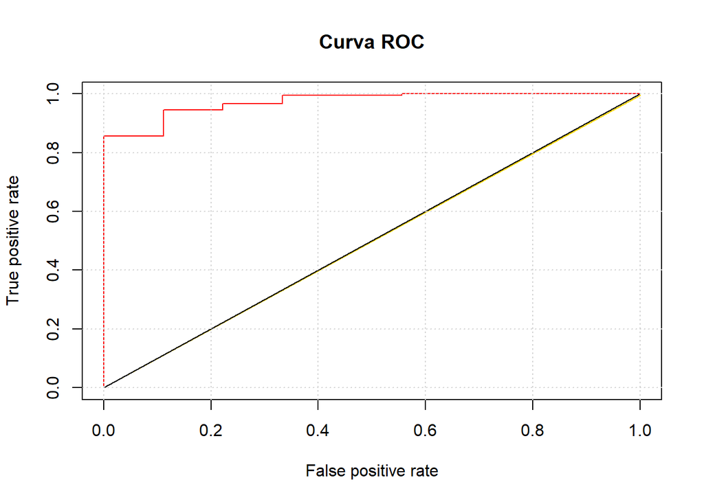

```r
Score6 <- prediccion6$prediction[,2]
Clase6 <- ttesting$tipo

Score7 <- prediccion7$prediction[,2]
Clase7 <- ttesting$tipo

Score8 <- prediccion8$prediction[,2]
Clase8 <- ttesting$tipo

Score9 <- prediccion9$prediction[,2]
Clase9 <- ttesting$tipo

Score10 <- prediccion10$prediction[,2]
Clase10 <- ttesting$tipo

Score11 <- prediccion11$prediction[,2]
Clase11 <- ttesting$tipo

plotROC(Score, Clase)
plotROC(Score2, Clase2, adicionar=TRUE, color = "blue")
plotROC(Score4, Clase4, adicionar = TRUE, color = "green")
plotROC(Score5, Clase5, adicionar = TRUE, color = "blueviolet")
plotROC(Score6, Clase6, adicionar = TRUE, color = "darkgoldenrod2")
plotROC(Score7, Clase7, adicionar = TRUE, color = "brown1")
plotROC(Score8, Clase8, adicionar = TRUE, color = "darkgreen")
plotROC(Score9, Clase9, adicionar = TRUE, color = "deeppink")
plotROC(Score10, Clase10, adicionar = TRUE, color = "gold")
plotROC(Score11, Clase11, adicionar = TRUE, color = "gray0")
```

```r
areaROC(Score5, Clase5)
```

```
## [1] 0.5
```

```r
areaROC(Score6, Clase6)
```

```
## [1] 0.4972527
```

```r
areaROC(Score7, Clase7)
```

```
## [1] 0.4972527
```

```r
areaROC(Score8, Clase8)
```

```
## [1] 0.5
```

```r
areaROC(Score9, Clase9)
```

```
## [1] 0.5
```

```r
areaROC(Score10, Clase10)
```

```
## [1] 0.4972527
```

```r
areaROC(Score11, Clase11)
```

```
## [1] 0.5
```

```r
modelo6 <- train.ada(tipo~.,data=taprendizaje,iter=80,nu=1,type="discrete")
prediccion6 <- predict(modelo6, ttesting, type = "prob")
head(prediccion6$prediction)
```

```
##                 0 1
## [1,] 2.299213e-22 1
## [2,] 1.904669e-12 1
## [3,] 6.808121e-22 1
## [4,] 2.821217e-17 1
## [5,] 6.286298e-18 1
## [6,] 1.011694e-20 1
```

```r
modelo7 <- train.ada(tipo~.,data=taprendizaje,iter=80,nu=1,type="real")
prediccion7 <- predict(modelo7, ttesting, type = "prob")
head(prediccion7$prediction)
```

```
##                 0 1
## 11   1.633932e-24 1
## 737  5.193057e-13 1
## 439  1.530173e-19 1
## 139  3.806257e-16 1
## 366  5.948807e-17 1
## 1092 3.673508e-19 1
```

```r
modelo8 <- train.ada(tipo~.,data=taprendizaje,iter=80,nu=1,type="gentle")
prediccion8 <- predict(modelo8, ttesting, type = "prob")
head(prediccion8$prediction)
```

```
##                 0 1
## 11   1.340739e-17 1
## 737  1.651048e-15 1
## 439  1.223126e-18 1
## 139  1.954801e-18 1
## 366  1.876947e-21 1
## 1092 1.474179e-18 1
```

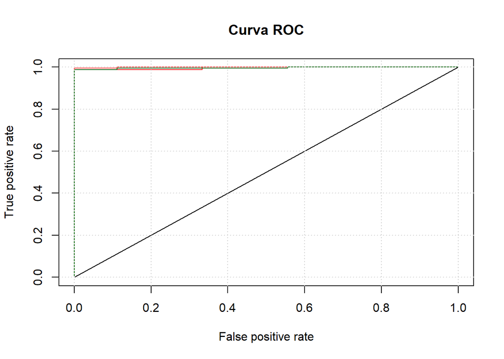

```r
Score6 <- prediccion6$prediction[,2]
Clase6 <- ttesting$tipo

Score7 <- prediccion7$prediction[,2]
Clase7 <- ttesting$tipo

Score8 <- prediccion8$prediction[,2]
Clase8 <- ttesting$tipo


plotROC(Score6, Clase6)
plotROC(Score7, Clase7, adicionar = TRUE, color = "brown1")
plotROC(Score8, Clase8, adicionar = TRUE, color = "darkgreen")
```

```r
areaROC(Score6, Clase6)
```

```
## [1] 0.996337
```

```r
areaROC(Score7, Clase7)
```

```
## [1] 0.9993895
```

```r
areaROC(Score8, Clase8)
```

```
## [1] 0.996337
```

```r
modelo <- train.svm(tipo ~ ., data = taprendizaje)
prediccion <- predict(modelo, ttesting, type = "prob")
head(prediccion$prediction)
```

```
##                0         1
## 11   0.025841648 0.9741584
## 737  0.023069980 0.9769300
## 439  0.010162115 0.9898379
## 139  0.006296721 0.9937033
## 366  0.003484026 0.9965160
## 1092 0.003362013 0.9966380
```

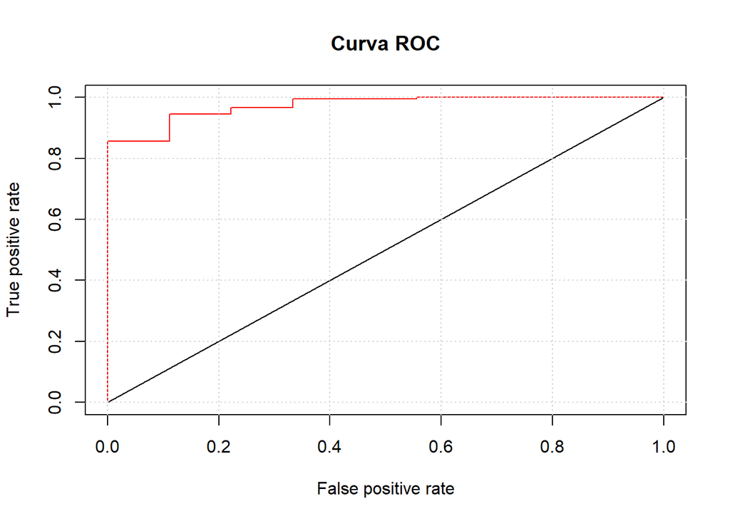

```r
Score <- prediccion$prediction[,2]
Clase <- ttesting$tipo
plotROC(Score,Clase)
```

```r
areaROC(Score,Clase) ##SVM
```

```
## [1] 0.973138
```

```r
library(e1071)
library(kknn)
library(MASS)
library(class)
library(rpart)
library(randomForest)
library(ada)
library(nnet)
library(caret)
library(traineR)
modelo2 <- train.ada(tipo~.,data=taprendizaje,iter=80,nu=1,type="discrete")
prediccion2 <- predict(modelo2, ttesting, type = "prob")
head(prediccion2$prediction)
```

```
##                 0 1
## [1,] 4.482960e-21 1
## [2,] 2.236236e-13 1
## [3,] 2.550052e-16 1
## [4,] 7.915981e-16 1
## [5,] 7.306432e-14 1
## [6,] 1.375744e-15 1
```

```r
consenso <- function(taprendizaje){
      largo <- dim(taprendizaje)[1]
      m1 <- sample(1:largo, replace=TRUE)
      ap1 <- taprendizaje[m1,]
      m2 <- sample(1:largo, replace=TRUE)
      ap2 <- taprendizaje[m2,]
      m3 <- sample(1:largo, replace=TRUE)
      ap3 <- taprendizaje[m3,]
      m4 <- sample(1:largo, replace=TRUE)
      ap4 <- taprendizaje[m4,]
      m5 <- sample(1:largo, replace=TRUE)
      ap5 <- taprendizaje[m5,]
      m6 <- sample(1:largo, replace=TRUE)
      ap6 <- taprendizaje[m6,]

      m9 <- sample(1:largo, replace=TRUE)
      ap9 <- taprendizaje[m9,]



      mod.knn<-train.knn(tipo~., data = ap1 , kmax=10)
      mod.redes<-nnet(tipo~ ., data = ap2, size = 4, rang= 0.1, decay = 5e-04,maxit = 500, trace = FALSE, MaxNWts=1500)
      mod.arboles<-rpart(tipo ~ ., data = ap3)
      mod.svm.1<-svm(tipo~ ., data = ap4, kernel="radial")
      mod.svm.2<-svm(tipo~ ., data = ap5, kernel="polynomial")
      mod.bayes <- naiveBayes(tipo~.,data=ap6)
      #mod.qda <- qda(Survived~., data=ap8)
      mod.ada<-ada(tipo~.,data=ap9,iter=10,nu=0.9)

      mod.consenso <- list(kvecinos=mod.knn,red.neuronal=mod.redes,arbol.decision=mod.arboles,SVM1=mod.svm.1,bayes=mod.bayes)
      return(list(kvecinos=mod.knn,red.neuronal=mod.redes,arbol.decision=mod.arboles,SVM1=mod.svm.1, bayes=mod.bayes))
}


library(modeest)
predice<-function(ttesting,mod.consenso){
      p.knn<-as.numeric(predict(mod.consenso$kvecinos, ttesting))
      p.red<-as.numeric(predict(mod.consenso$red.neuronal, ttesting, type = "class"))
      p.arbol<-as.numeric(predict(mod.consenso$arbol.decision, ttesting, type = "class"))
      p.svm1<-as.numeric(predict(mod.consenso$SVM1, ttesting, type = "class"))
      p.bayes <-as.numeric(predict(mod.consenso$bayes,ttesting))

      auxiliar <- p.knn-1

      votos<-data.frame(p.knn,p.red,p.arbol,p.svm1,p.bayes)
      votos$p.knn<-votos$p.knn-1
      votos$p.arbol<-votos$p.arbol-1
      votos$p.svm1<-votos$p.svm1-1
      votos$p.bayes<-votos$p.bayes-1


      modas <-  rep(0,dim(votos)[1])
      for (i in 1:dim(votos)[1]){
        modas[i]<-mfv(as.numeric(votos[i,]))
      }
      confusion<-table(ttesting$tipo,modas)
      return(confusion)

}

# mod.consenso <- consenso(taprendizaje)
# pred.consenso<-predice(ttesting, mod.consenso)
# head(pred.consenso$prediction)
    # MC <- indices.general(pred.consenso)
    # no.consenso <- no.consenso + MC$`Matriz de Confusión`["1","1"]
    # error.consenso <- error.consenso +(1-(sum(diag(MC$`Matriz de Confusión`)))/sum(MC$`Matriz de Confusión`))*100

modelo4 <- lda(tipo~., data=taprendizaje)
prediccion4 <- predict(modelo4, ttesting)
head(prediccion4$prediction)
```

```r
modelo3 <- train.bayes(tipo ~ ., data = taprendizaje)
prediccion3 <- predict(modelo3, ttesting, type = "prob")
head(prediccion3$prediction)
```

```
##                 0         1
## [1,] 3.146101e-07 0.9999997
## [2,] 2.467187e-05 0.9999753
## [3,] 1.069252e-01 0.8930748
## [4,] 1.208620e-06 0.9999988
## [5,] 2.862477e-06 0.9999971
## [6,] 3.738120e-07 0.9999996
```

```r
modelo7 <- train.knn(tipo ~ ., data = taprendizaje,  kmax = 100, kernel = "biweight")
prediccion7 <- predict(modelo7, ttesting, type = "prob")
head(prediccion7$prediction)
```

```
##               0 1
## [1,] 0.00000000 1
## [2,] 0.05375467 1
## [3,] 0.00000000 1
## [4,] 0.00000000 1
## [5,] 0.00000000 1
## [6,] 0.00000000 1
```

```r
modelo6 <- train.rpart(tipo ~ ., data = taprendizaje)
prediccion6 <- predict(modelo6, ttesting, type = "prob")
head(prediccion6$prediction)
```

```
##      0 1
## 11   0 1
## 737  0 1
## 439  0 1
## 139  0 1
## 366  0 1
## 1092 0 1
```

```r
modelo8 <- train.randomForest(tipo ~ ., data = taprendizaje)
prediccion8 <- predict(modelo8, ttesting, type = "prob")
head(prediccion8$prediction)
```

```
##         0    1
## 11   0.00 1.00
## 737  0.03 0.97
## 439  0.00 1.00
## 139  0.00 1.00
## 366  0.00 1.00
## 1092 0.00 1.00
```

```r
modelo9 <- train.nnet(tipo ~ ., data = taprendizaje, size = 100, MaxNWts = 5000, rang = 0.01, decay = 5e-4, maxit = 45, trace = TRUE)
prediccion9 <- predict(modelo9, ttesting, type = "prob")
head(prediccion9$prediction)
```

```
##               0         1
## 11   0.12878972 0.8712103
## 737  0.02574669 0.9742533
## 439  0.07889378 0.9211062
## 139  0.12852761 0.8714724
## 366  0.11660251 0.8833975
## 1092 0.04686557 0.9531344
```

```r
modelo10 <- train.xgboost(tipo ~ ., data = taprendizaje, nrounds = 79, print_every_n = 10, maximize = F , eval_metric = "error")
prediccion10 <- predict(modelo10, ttesting, type = "prob")
head(prediccion10$prediction)
```

```
##                 0         1
## [1,] 0.0001615286 0.9998385
## [2,] 0.0005547404 0.9994453
## [3,] 0.0002618432 0.9997382
## [4,] 0.0007538795 0.9992461
## [5,] 0.0007260442 0.9992740
## [6,] 0.0005109310 0.9994891
```

```r
modelo11 <- train.neuralnet(tipo ~., data = taprendizaje, hidden = c(8,6,4), linear.output = FALSE, threshold = 0.5, stepmax = 1e+06)
prediccion11 <- predict(modelo11, ttesting, type = "prob")
head(prediccion11$prediction)
```

```
##               0         1
## 11   0.07844991 0.9174083
## 737  0.07843314 0.9217608
## 439  0.08059045 0.9110054
## 139  0.07843314 0.9217608
## 366  0.07843314 0.9217608
## 1092 0.07843314 0.9217608
```

```r
modelo12 <- train.glm(tipo ~ ., data = taprendizaje)
prediccion12 <- predict(modelo12, ttesting, type = "prob")
head(prediccion12$prediction)
```

```
##                 0            1
## [1,] 2.220446e-16 1.000000e+00
## [2,] 1.000000e+00 2.220446e-16
## [3,] 2.220446e-16 1.000000e+00
## [4,] 1.000000e+00 2.220446e-16
## [5,] 1.000000e+00 2.220446e-16
## [6,] 2.220446e-16 1.000000e+00
```

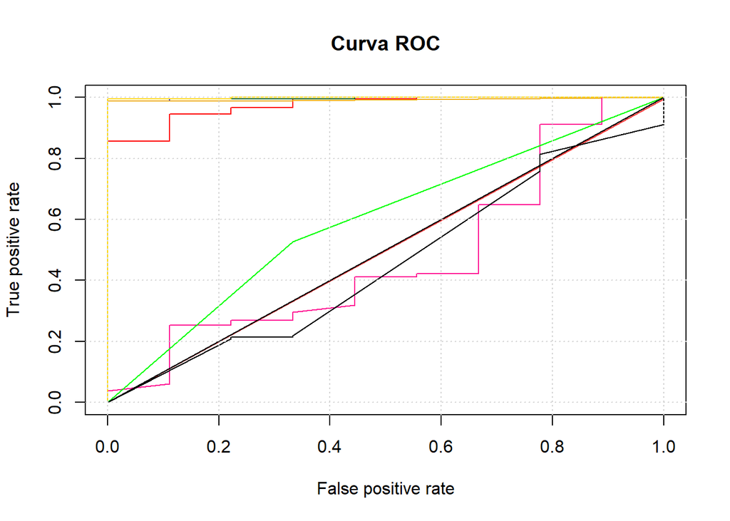

```r
Score <- prediccion$prediction[,2]
Clase <- ttesting$tipo

Score2 <- prediccion2$prediction[,2]
Clase2 <- ttesting$tipo

Score3 <- prediccion3$prediction[,2]
Clase3 <- ttesting$tipo

Score4 <- prediccion4$prediction[,2]
Clase4 <- ttesting$tipo

Score6 <- prediccion6$prediction[,2]
Clase6 <- ttesting$tipo

Score7 <- prediccion7$prediction[,2]
Clase7 <- ttesting$tipo

Score8 <- prediccion8$prediction[,2]
Clase8 <- ttesting$tipo

Score9 <- prediccion9$prediction[,2]
Clase9 <- ttesting$tipo

Score10 <- prediccion10$prediction[,2]
Clase10 <- ttesting$tipo

Score11 <- prediccion11$prediction[,2]
Clase11 <- ttesting$tipo

Score12 <- prediccion12$prediction[,2]
Clase12 <- ttesting$tipo

plotROC(Score, Clase)
plotROC(Score2, Clase2, adicionar=TRUE, color = "blue")
#plotROC(Score4, Clase4, adicionar = TRUE, color = "green")
plotROC(Score5, Clase5, adicionar = TRUE, color = "blueviolet")
plotROC(Score6, Clase6, adicionar = TRUE, color = "darkgoldenrod2")
plotROC(Score7, Clase7, adicionar = TRUE, color = "brown1")
plotROC(Score8, Clase8, adicionar = TRUE, color = "darkgreen")
plotROC(Score9, Clase9, adicionar = TRUE, color = "deeppink")
plotROC(Score10, Clase10, adicionar = TRUE, color = "gold")
plotROC(Score11, Clase11, adicionar = TRUE, color = "gray0")
plotROC(Score12, Clase12, adicionar = TRUE, color = "green")
```

2. Calcule en ´area bajo curva ROC para todos los modelos predictivos generados en la tarea anterior. ¿Cu´al m´etodo es el mejor seg´un este criterio?

```r
areaROC(Score,Clase) #SVM
```

```
## [1] 0.973138
```

```r
areaROC(Score2, Clase2) #ADA
```

```
## [1] 0.9969475
```

```r
areaROC(Score3, Clase3)
```

```
## [1] 0.9438339
```

```r
#areaROC(Score4, Clase4)
areaROC(Score6, Clase6) ##rpart
```

```
## [1] 0.9932845
```

```r
areaROC(Score7, Clase7)
```

```
## [1] 0.4972527
```

```r
areaROC(Score8, Clase8)##aleatorios
```

```
## [1] 0.997558
```

```r
areaROC(Score9, Clase9)
```

```
## [1] 0.4749695
```

```r
areaROC(Score10, Clase10) #XGBoosting
```

```
## [1] 0.998779
```

```r
areaROC(Score11, Clase11)
```

```
## [1] 0.456044
```

```r
areaROC(Score12, Clase12)
```

```
## [1] 0.5970696
```

Se denorta que lo mejor desempeno tiene para este calculo es XGBoosting seguido por los tres mencionados anteriormente, por un margen bastante pequeno ya que los cuatro superan un 0,99 de poder predictivo en ada-discrete, arboles de decision y bosques aleatorios. Para esto tomando el criterio de grafico de curva ROC, junto al area bajo la curva.

Ejercicio 2: [30 puntos] Dada la siguiente tabla:

1. Usando la definici´on de curva ROC calcule y grafique “a mano” la curva ROC, use un umbral T = 0 y un paso de 0,05. Es decir, debe hacerlo variando el umbral y calculando las matrices de confusi´on.

##Ver archivo Excel adjunto

2. Verifique el resultado anterior usando el c´odigo visto en clase.

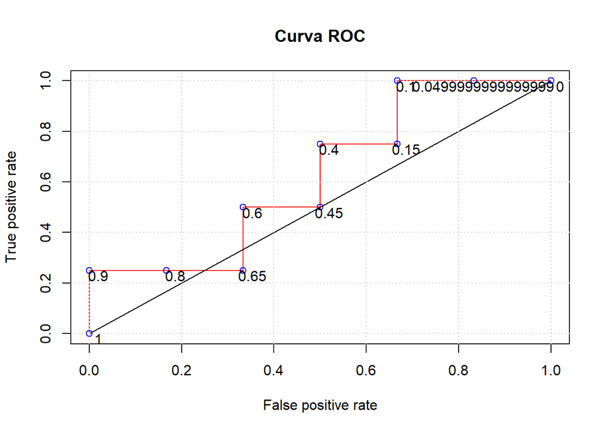

```
## Punto i =  1
## Umbral = T =  1
## MC =
##      Pred
## Clase 0 1
##     0 6 0
##     1 4 0
## Tasa FP =  0
## Tasa TP =  0
##
## Punto i =  2
## Umbral = T =  0.9
## MC =
##      Pred
## Clase 0 1
##     0 6 0
##     1 3 1
## Tasa FP =  0
## Tasa TP =  0.25
##
## Punto i =  3
## Umbral = T =  0.8
## MC =
##      Pred
## Clase 0 1
##     0 5 1
##     1 3 1
## Tasa FP =  0.17
## Tasa TP =  0.25
##
## Punto i =  4
## Umbral = T =  0.65
## MC =
##      Pred
## Clase 0 1
##     0 4 2
##     1 3 1
## Tasa FP =  0.33
## Tasa TP =  0.25
##
```

[output cut: 54 more lines]

```
## Clase 0 1
##     0 1 5
##     1 0 4
## Tasa FP =  0.83
## Tasa TP =  1
##
## Punto i =  11
## Umbral = T =  0
## MC =
##      Pred
## Clase 0 1
##     0 0 6
##     1 0 4
## Tasa FP =  1
## Tasa TP =  1
```

```r
library(ROCR)

Clase <- c(0,1,0,1,0,0,1,0,1,0)
Score <- c(0.8,0.11,0.66,0.4,0.00,0.46,0.61,0.06,0.91,0.19)

# Graficamos ROC con funciones de paquete ROCR
plotROC(Score, Clase)

# Graficamos puntos con algoritmo
i <- 1  # Contador
FP_r <- -1  # Para que entre al condicional en la primera iteración
TP_r <- -1  # Para que entre al condicional en la primera iteración

for(Umbral in seq(1, 0, by = -0.05)) {

  Prediccion <- ifelse(Score >= Umbral, 1, 0)

  MC <- table(Clase, Pred = factor(Prediccion, levels = c(0, 1)))

  # Condicional para no imprimir puntos repetidos
  if(FP_r != MC[1, 2] / sum(MC[1, ]) | TP_r != MC[2, 2] / sum(MC[2, ])) {

    FP_r <- MC[1, 2] / sum(MC[1, ])  # Tasa de Falsos Positivos
    TP_r <- MC[2, 2] / sum(MC[2, ])  # Tasa de Verdaderos Positivos

    # Graficamos punto
    points(FP_r, TP_r, col = "blue")
    text(FP_r + 0.02, TP_r - 0.02, Umbral)

    # Imprimimos resultados
    cat("Punto i = ", i, "\n")
    cat("Umbral = T = ", Umbral, "\n")
    cat("MC = \n")
    print(MC)
    cat("Tasa FP = ", round(FP_r, 2), "\n")
    cat("Tasa TP = ", round(TP_r, 2), "\n")
    cat("\n")

    i <- i + 1  # Aumentamos contador

  }

}
```

3. Usando el algoritmo eficiente para la curva ROC calcule y grafique “a mano” la curva ROC, use un umbral T = 0,1 y un paso de 0,1.

##Ver archivo Excel adjunto

4. Verifique el resultado anterior usando el c´odigo visto en clase para el algoritmo eficiente.

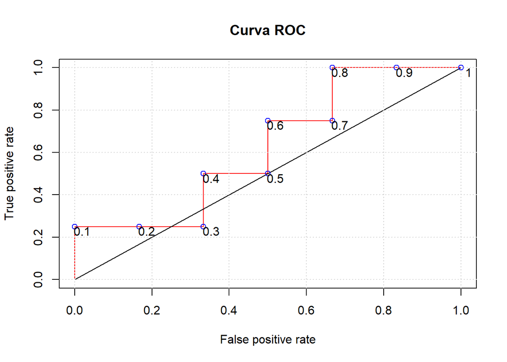

```
## Punto i =  1
## Umbral = T =  0.1
## FP/N =  0
## TP/P =  0.25
##
## Punto i =  2
## Umbral = T =  0.2
## FP/N =  0.17
## TP/P =  0.25
##
## Punto i =  3
## Umbral = T =  0.3
## FP/N =  0.33
## TP/P =  0.25
##
## Punto i =  4
## Umbral = T =  0.4
## FP/N =  0.33
## TP/P =  0.5
##
## Punto i =  5
## Umbral = T =  0.5
## FP/N =  0.5
## TP/P =  0.5
##
## Punto i =  6
## Umbral = T =  0.6
## FP/N =  0.5
## TP/P =  0.75
##
## Punto i =  7
## Umbral = T =  0.7
## FP/N =  0.67
## TP/P =  0.75
##
## Punto i =  8
## Umbral = T =  0.8
## FP/N =  0.67
## TP/P =  1
##
## Punto i =  9
## Umbral = T =  0.9
## FP/N =  0.83
## TP/P =  1
##
## Punto i =  10
## Umbral = T =  1
## FP/N =  1
## TP/P =  1
```

```r
library(ROCR)

Clase <- c(1,0,0,1,0,1,0,1,0,0)
Score <- c(.91, .80, .66, .61, .46, .40, .19, .11, .06, .00)

plotROC(Score, Clase)

# Aquí se inicializan para que dé igual a la corrida a pie
Umbral <- 0.1
Paso <- 0.1

N <- 6 # ceros
P <- 4 # unos

TP <- 0
FP <- 0

for(i in 1:10) {

  if(Score[i] > Umbral)
    if(Clase[i] == 1)
      TP <- TP + 1
    else
      FP <- FP + 1
    else
      if(Clase[i] == 0)
        FP <- FP + 1
      else
        TP <- TP + 1

      # Graficamos punto
      points(FP / N, TP / P, col = "blue")
      text(FP / N + 0.02, TP/P - 0.02, round(Umbral, 2))

      # Imprimimos resultado
      cat("Punto i = ", i, "\n")
      cat("Umbral = T = ", Umbral, "\n")
      cat("FP/N = ", round(FP / N, 2), "\n")
      cat("TP/P = ", round(TP / P, 2), "\n")
      cat("\n")

      Umbral <- Umbral + Paso
}
```

Ejercicio 3: [30 puntos] Esta pregunta utiliza los datos SAheart.csv sobre muerte del coraz´on en Sud´africa. La variable que queremos predecir es chd que es un indicador de muerte coronaria basado en algunas variables predictivas (factores de riesgo) como son el fumado, la obesidad, las bebidas alcoh´olicas, entre otras. Las variables son: Realice lo siguiente:

1. Usando Bosques Aleatorios (train.randomForest(…) del paquete traineR) para la tabla SAheart.csv con el 80 % de los datos para la tabla aprendizaje y un 20 % para la tabla testing determine la mejor Probabilidad de Corte, de forma tal que se prediga de la mejor manera posible la categor´ıa Si de la variable chd, pero sin desmejorar de manera significativa la precisi´on global.

```r
setwd("C:/Users/rzamoram/OneDrive - Intel Corporation/Documents/Machine Learning/Mineria de Datos I/Clase1")
datos<-read.csv("SAheart.csv",sep=';',dec='.',header=T)
head(datos)
```

```
##   sbp tobacco  ldl adiposity famhist typea obesity alcohol age chd
## 1 160   12.00 5.73     23.11 Present    49   25.30   97.20  52  Si
## 2 144    0.01 4.41     28.61  Absent    55   28.87    2.06  63  Si
## 3 118    0.08 3.48     32.28 Present    52   29.14    3.81  46  No
## 4 170    7.50 6.41     38.03 Present    51   31.99   24.26  58  Si
## 5 134   13.60 3.50     27.78 Present    60   25.99   57.34  49  Si
## 6 132    6.20 6.47     36.21 Present    62   30.77   14.14  45  No
```

```r
library(caret)
summary(datos)
```

```
##       sbp           tobacco             ldl           adiposity
##  Min.   :101.0   Min.   : 0.0000   Min.   : 0.980   Min.   : 6.74
##  1st Qu.:124.0   1st Qu.: 0.0525   1st Qu.: 3.283   1st Qu.:19.77
##  Median :134.0   Median : 2.0000   Median : 4.340   Median :26.11
##  Mean   :138.3   Mean   : 3.6356   Mean   : 4.740   Mean   :25.41
##  3rd Qu.:148.0   3rd Qu.: 5.5000   3rd Qu.: 5.790   3rd Qu.:31.23
##  Max.   :218.0   Max.   :31.2000   Max.   :15.330   Max.   :42.49
##     famhist        typea         obesity         alcohol            age
##  Absent :270   Min.   :13.0   Min.   :14.70   Min.   :  0.00   Min.   :15.00
##  Present:192   1st Qu.:47.0   1st Qu.:22.98   1st Qu.:  0.51   1st Qu.:31.00
##                Median :53.0   Median :25.80   Median :  7.51   Median :45.00
##                Mean   :53.1   Mean   :26.04   Mean   : 17.04   Mean   :42.82
##                3rd Qu.:60.0   3rd Qu.:28.50   3rd Qu.: 23.89   3rd Qu.:55.00
##                Max.   :78.0   Max.   :46.58   Max.   :147.19   Max.   :64.00
##  chd
##  No:302
##  Si:160
##
##
##
##
```

```r
datos$chd <- factor(datos$chd,ordered = TRUE)
datos$famhist <- factor(datos$famhist,ordered = TRUE)
str(datos)
```

```
## 'data.frame':    462 obs. of  10 variables:
##  $ sbp      : int  160 144 118 170 134 132 142 114 114 132 ...
##  $ tobacco  : num  12 0.01 0.08 7.5 13.6 6.2 4.05 4.08 0 0 ...
##  $ ldl      : num  5.73 4.41 3.48 6.41 3.5 6.47 3.38 4.59 3.83 5.8 ...
##  $ adiposity: num  23.1 28.6 32.3 38 27.8 ...
##  $ famhist  : Ord.factor w/ 2 levels "Absent"<"Present": 2 1 2 2 2 2 1 2 2 2 ...
##  $ typea    : int  49 55 52 51 60 62 59 62 49 69 ...
##  $ obesity  : num  25.3 28.9 29.1 32 26 ...
##  $ alcohol  : num  97.2 2.06 3.81 24.26 57.34 ...
##  $ age      : int  52 63 46 58 49 45 38 58 29 53 ...
##  $ chd      : Ord.factor w/ 2 levels "No"<"Si": 2 2 1 2 2 1 1 2 1 2 ...
```

```r
dim(datos)
```

```
## [1] 462  10
```

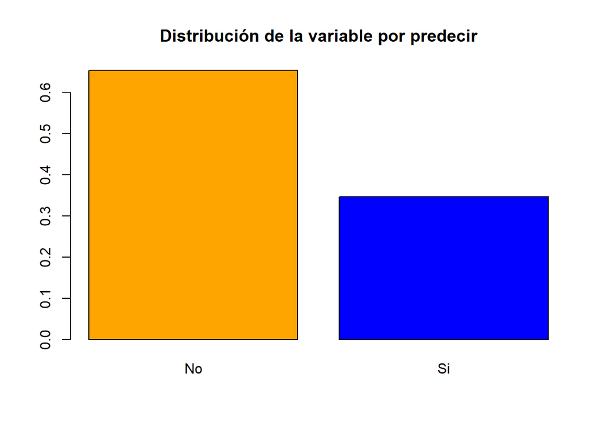

```r
barplot(prop.table(table(datos$chd)),col=c("orange","blue","green"),main="Distribución de la variable por predecir")
```

El problema esta desbalanceado

```r
muestra <- sample(1:nrow(datos),floor(nrow(datos)*0.20))
ttesting <- datos[muestra,]
taprendizaje <- datos[-muestra,]
modelo <- train.randomForest(chd ~ ., data = taprendizaje)
prediccion <- predict(modelo, ttesting)
MC <- confusion.matrix(ttesting, prediccion)
general.indexes(mc=MC)
```

```
##
## Confusion Matrix:
##     prediction
## real No Si
##   No 53 12
##   Si 12 15
##
## Overall Accuracy: 0.7391
## Overall Error:    0.2609
##
## Category Accuracy:
##
##            No           Si
##      0.815385     0.555556
```

```r
prediccion <- predict(modelo, ttesting, type = "prob")
Clase <- ttesting[,10]
head(Clase)
```

```
## [1] Si No Si No No No
## Levels: No < Si
```

```r
Score <- prediccion$prediction[,2]
head(Score)
```

```
##   150   293   233    71   427   318
## 0.514 0.316 0.362 0.012 0.580 0.098
```

```r
Corte <- 0.5
Prediccion <- ifelse(Score > Corte, "Si", "No")
MC <- table(Clase, Pred = factor(Prediccion, levels = c("No", "Si")))
general.indexes(mc=MC)
```

```
##
## Confusion Matrix:
##      Pred
## Clase No Si
##    No 53 12
##    Si 13 14
##
## Overall Accuracy: 0.7283
## Overall Error:    0.2717
##
## Category Accuracy:
##
##            No           Si
##      0.815385     0.518519
```

```r
# Con Corte en Probabilidad = 0.7, da diferente
Clase <- ttesting[,10]
Score <- prediccion$prediction[,2]
Corte <- 0.7
Prediccion <- ifelse(Score >= Corte, "Si", "No")
MC <- table(Clase, Pred = factor(Prediccion, levels = c("No", "Si")))
general.indexes(mc=MC)
```

```
##
## Confusion Matrix:
##      Pred
## Clase No Si
##    No 62  3
##    Si 20  7
##
## Overall Accuracy: 0.7500
## Overall Error:    0.2500
##
## Category Accuracy:
##
##            No           Si
##      0.953846     0.259259
```

```r
Clase <- ttesting[,10]
Score <- prediccion$prediction[,2]
for(Corte in seq(1, 0, by = -0.05)) {
  Prediccion <- ifelse(Score >= Corte, "Si", "No")
  MC <- table(Clase, Pred = factor(Prediccion, levels = c("No", "Si")))
  cat("\nCorte usado para la Probabilidad = ")
  cat(Corte)
  cat("\n")
  print(general.indexes(mc=MC))
  cat("\n========================================")
}
```

```
##
## Corte usado para la Probabilidad = 1
##
## Confusion Matrix:
##      Pred
## Clase No Si
##    No 65  0
##    Si 27  0
##
## Overall Accuracy: 0.7065
## Overall Error:    0.2935
##
## Category Accuracy:
##
##            No           Si
##      1.000000     0.000000
## ========================================
## Corte usado para la Probabilidad = 0.95
##
## Confusion Matrix:
##      Pred
## Clase No Si
##    No 65  0
##    Si 27  0
##
## Overall Accuracy: 0.7065
## Overall Error:    0.2935
##
## Category Accuracy:
##
##            No           Si
##      1.000000     0.000000
## ========================================
## Corte usado para la Probabilidad = 0.9
##
## Confusion Matrix:
##      Pred
## Clase No Si
##    No 65  0
##    Si 27  0
```

[output cut: 282 more lines]

```
##
## Confusion Matrix:
##      Pred
## Clase No Si
##    No  0 65
##    Si  0 27
##
## Overall Accuracy: 0.2935
## Overall Error:    0.7065
##
## Category Accuracy:
##
##            No           Si
##      0.000000     1.000000
## ========================================
```

Se denota que conforme aumenta la probabilidad de corte la precision global aumenta, pero opuesto parece disminuir la precision por categoria de Si en la variable. A partir de probabilidad de corte de 0.5 la precision de prediccion de Si se viene abajo de 0,50, en este caso, se vuelve poco servible. Pero por otro lado la precision global del modelo es inferior a 0,50 cuando la probabilidad de corte es menor de 0.1. Parece que elegir un punto entre estos conviene para maximizar la precision y la precision del Si, desde un punto de vista personal la probabilidad de corte deberia estar segun las indicaciones de este modelo en 0.35, ya que es aqui donde las precisiones llegan a puntos similares la categoria Si llega a 0.666667 y la exactitud del modelo se estima en 0.6522, es decir, en ambas estimaciones parece estar parecido.

2. Repita el ejercicio anterior usando XGBoosting. ¿Cambi´o la probabilidad de corte? Explique.

```r
modelo <- train.xgboost(chd ~ ., data = taprendizaje, nrounds = 79, print_every_n = 10, maximize = F , eval_metric = "error")
prediccion <- predict(modelo, ttesting)
MC <- confusion.matrix(ttesting, prediccion)
general.indexes(mc=MC)
```

```
##
## Confusion Matrix:
##     prediction
## real No Si
##   No 49 16
##   Si 14 13
##
## Overall Accuracy: 0.6739
## Overall Error:    0.3261
##
## Category Accuracy:
##
##            No           Si
##      0.753846     0.481481
```

```r
prediccion <- predict(modelo, ttesting, type = "prob")
Clase <- ttesting[,10]
head(Clase)
```

```
## [1] Si No Si No No No
## Levels: No < Si
```

```r
Score <- prediccion$prediction[,2]
head(Score)
```

```
## [1] 0.063358039 0.039926171 0.134305328 0.000428004 0.751527846 0.024036504
```

```r
Clase <- ttesting[,10]
Score <- prediccion$prediction[,2]
for(Corte in seq(1, 0, by = -0.05)) {
  Prediccion <- ifelse(Score >= Corte, "Si", "No")
  MC <- table(Clase, Pred = factor(Prediccion, levels = c("No", "Si")))
  cat("\nCorte usado para la Probabilidad = ")
  cat(Corte)
  cat("\n")
  print(general.indexes(mc=MC))
  cat("\n========================================")
}
```

```
##
## Corte usado para la Probabilidad = 1
##
## Confusion Matrix:
##      Pred
## Clase No Si
##    No 65  0
##    Si 27  0
##
## Overall Accuracy: 0.7065
## Overall Error:    0.2935
##
## Category Accuracy:
##
##            No           Si
##      1.000000     0.000000
## ========================================
## Corte usado para la Probabilidad = 0.95
##
## Confusion Matrix:
##      Pred
## Clase No Si
##    No 61  4
##    Si 24  3
##
## Overall Accuracy: 0.6957
## Overall Error:    0.3043
##
## Category Accuracy:
##
##            No           Si
##      0.938462     0.111111
## ========================================
## Corte usado para la Probabilidad = 0.9
##
## Confusion Matrix:
##      Pred
## Clase No Si
##    No 60  5
##    Si 23  4
```

[output cut: 282 more lines]

```
##
## Confusion Matrix:
##      Pred
## Clase No Si
##    No  0 65
##    Si  0 27
##
## Overall Accuracy: 0.2935
## Overall Error:    0.7065
##
## Category Accuracy:
##
##            No           Si
##      0.000000     1.000000
## ========================================
```

Existe una situacion similar, es decir, conforme aumenta la probabilidad de corte la precision global aumenta, pero opuesto parece disminuir la precision por categoria de Si en la variable. A partir de probabilidad de corte de 0.5 la precision de prediccion de Si se viene abajo de 0,50, en este caso, se vuelve poco servible. Pero por otro lado la precision global del modelo es inferior a 0,50 cuando la probabilidad de corte es menor. Parece que elegir un punto entre estos conviene para maximizar la precision y la precision del Si, desde un punto de vista personal la probabilidad de corte deberia estar segun las indicaciones de este modelo en 0.2 o tambien 0,15 donde las estimacion son iguales, ya que es aqui donde las precisiones llegan a puntos similares la categoria Si llega a 0.636364 y la exactitud del modelo se estima en 0.6630, es decir, en ambas estimaciones parece estar parecido.